# CUNY 622 - Homework 2

Peter Kowalchuk

4/11/2020

```r
library(kableExtra)
library(ggplot2)

library(e1071)
library(MASS)
library(caret)
library(naivebayes)
library(C50)

library(partykit)
library(pROC)
```

# Import Data

```r
data<-read.csv("dataset.csv")
data %>% kable() %>% kable_styling() %>% scroll_box(width = "800px", height = "400px")
```

| X | Y | label |
| --- | --- | --- |
| 5 | a | BLUE |
| 5 | b | BLACK |
| 5 | c | BLUE |
| 5 | d | BLACK |
| 5 | e | BLACK |
| 5 | f | BLACK |
| 19 | a | BLUE |
| 19 | b | BLUE |
| 19 | c | BLUE |
| 19 | d | BLUE |
| 19 | e | BLACK |
| 19 | f | BLUE |
| 35 | a | BLACK |
| 35 | b | BLACK |
| 35 | c | BLUE |
| 35 | d | BLACK |
| 35 | e | BLACK |
| 35 | f | BLACK |
| 51 | a | BLACK |
| 51 | b | BLACK |
| 51 | c | BLUE |
| 51 | d | BLACK |
| 51 | e | BLACK |
| 51 | f | BLACK |
| 55 | a | BLACK |
| 55 | b | BLACK |
| 55 | c | BLACK |
| 55 | d | BLACK |
| 55 | e | BLACK |
| 55 | f | BLACK |
| 63 | a | BLACK |
| 63 | b | BLUE |
| 63 | c | BLUE |
| 63 | d | BLUE |
| 63 | e | BLUE |
| 63 | f | BLUE |

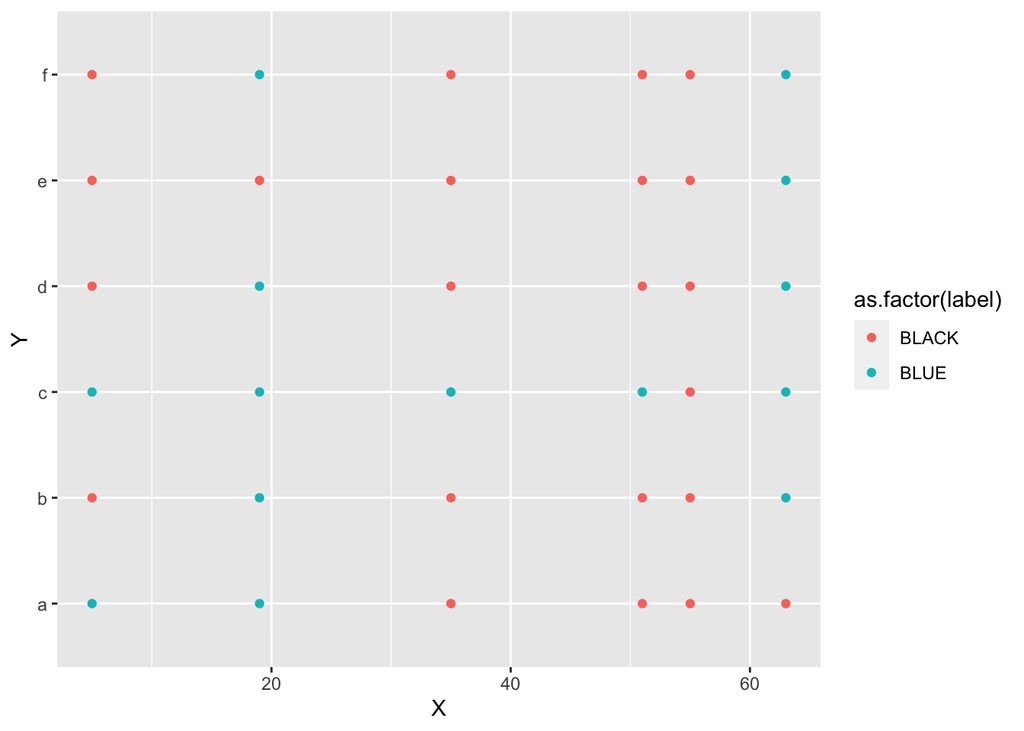

```r
ggplot(data,aes(y=Y,x=X,color=as.factor(label))) + geom_point()
```

# Split data

```r
set.seed(300)
#Spliting data as training and test set. Using createDataPartition() function from caret
indxTrain <- createDataPartition(y = data$label,p = 0.75,list = FALSE)
data_train <- data[indxTrain,]
data_test <- data[-indxTrain,]

#Checking distibution in origanl data and partitioned data
prop.table(table(data_train$label)) * 100
```

```
##
##    BLACK     BLUE
## 60.71429 39.28571
```

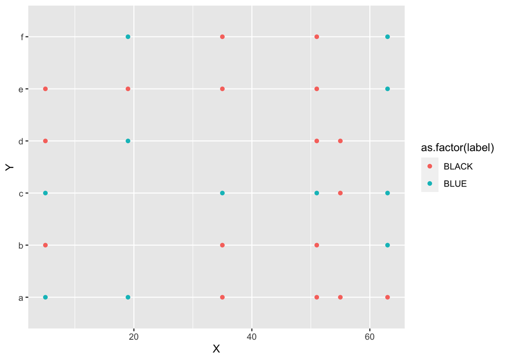

```r
ggplot(data_train,aes(y=Y,x=X,color=as.factor(label))) + geom_point()
```

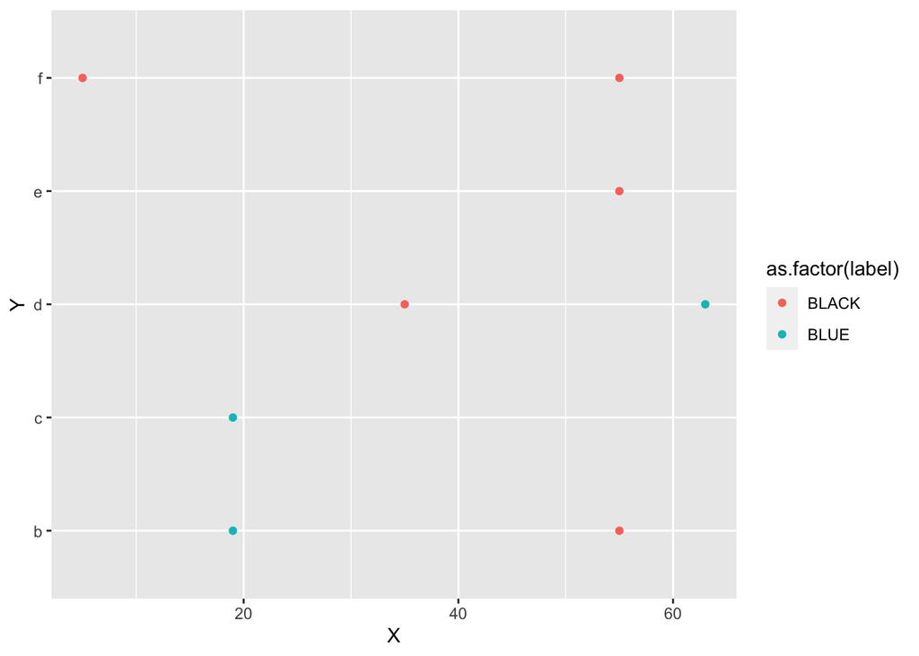

```r
ggplot(data_test,aes(y=Y,x=X,color=as.factor(label))) + geom_point()
```

# Run Models

## kNN

To determine K we use a “rule of thumb”, k is the square rooth of the number of samples

```r
k=round(length(data_train[,1])**0.5,0)
```

We use the class library to obtain the model. This class does not take non-numeric features, we transfor feature Y to intergers

```r
data_train_knn<-data_train
data_train_knn$Y<-apply(as.data.frame(data_train_knn$Y),1,utf8ToInt)
data_test_knn<-data_test
data_test_knn$Y<-apply(as.data.frame(data_test_knn$Y),1,utf8ToInt)
```

```r
knn_model <- class::knn(cl = data_train$label,
                  test = data_test_knn[,1:2],
                  train = data_train_knn[,1:2],
                  k = 5,
                  prob = TRUE)
```

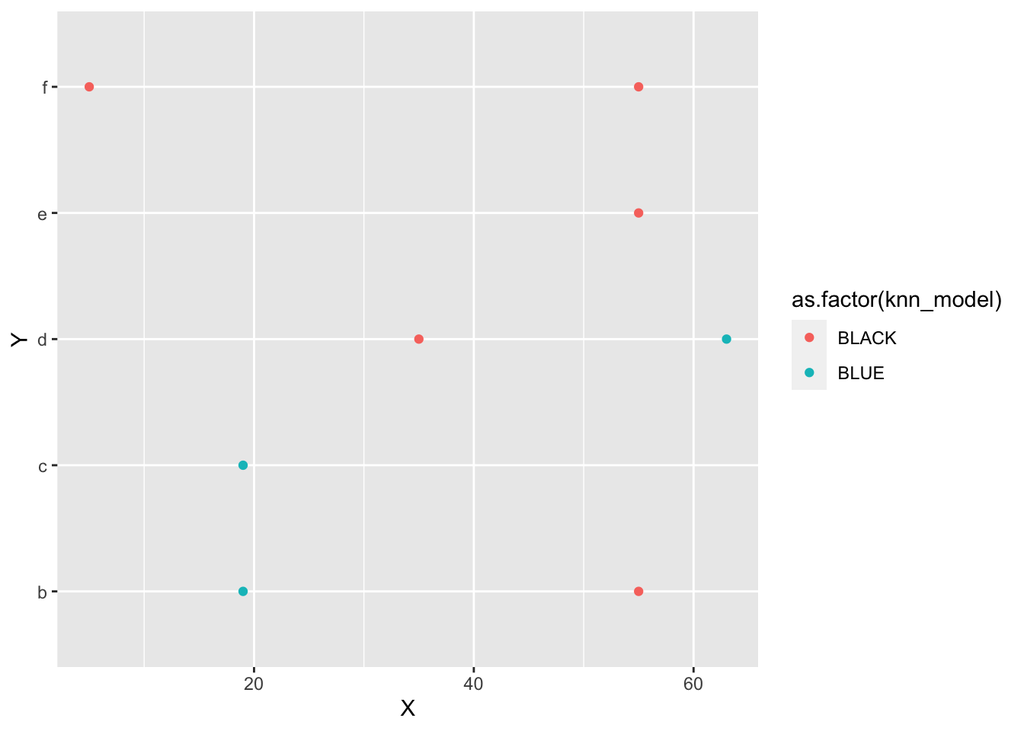

```r
ggplot(data_test,aes(y=Y,x=X,color=as.factor(knn_model))) + geom_point()
```

**Confusion Matrix**

```r
print("BLACK are positives")
```

```
## [1] "BLACK are positives"
```

```r
(confusion_matrix<-table(knn_model,data_test[,3]))
```

```
##
## knn_model BLACK BLUE
##     BLACK     5    0
##     BLUE      0    3
```

**AUC**

```r
(knn_auc<-roc(data_test$label, attributes(knn_model)$prob)$auc)
```

```
## Area under the curve: 0.7667
```

**ACC**

```r
(knn_acc<-sum(diag(confusion_matrix))/sum(confusion_matrix))
```

```
## [1] 1
```

**TPR**

```r
knn_tp<-confusion_matrix[1,1]
print(paste("Number of true positives=",knn_tp))
```

```
## [1] "Number of true positives= 5"
```

```r
knn_tpr<-confusion_matrix[1,1]/sum(confusion_matrix[,1])
print(paste("True positive ratio=",knn_tpr))
```

```
## [1] "True positive ratio= 1"
```

**FPR**

```r
knn_fp<-confusion_matrix[2,1]
print(paste("Number of false positives=",knn_fp))
```

```
## [1] "Number of false positives= 0"
```

```r
knn_fpr<-confusion_matrix[2,1]/sum(confusion_matrix[,1])
print(paste("False positive ratio=",knn_fpr))
```

```
## [1] "False positive ratio= 0"
```

**Best K**

We can use the caret library to check our selection of k. This library can run several k and selects the best performing

```r
knn_model<-train(label~.,data=data_train,method="knn",tuneLength=10)
knn_model
```

```
## k-Nearest Neighbors
##
## 28 samples
##  2 predictor
##  2 classes: 'BLACK', 'BLUE'
##
## No pre-processing
## Resampling: Bootstrapped (25 reps)
## Summary of sample sizes: 28, 28, 28, 28, 28, 28, ...
## Resampling results across tuning parameters:
##
##   k   Accuracy   Kappa
##    5  0.6292378   0.232282563
##    7  0.5731430   0.132921615
##    9  0.5322416   0.048896058
##   11  0.5229425   0.022845761
##   13  0.5515890   0.035252248
##   15  0.5603566   0.020510936
##   17  0.5619728  -0.010601504
##   19  0.5466395  -0.022469636
##   21  0.5139122  -0.005430702
##   23  0.5062758   0.002689412
##
## Accuracy was used to select the optimal model using the largest value.
## The final value used for the model was k = 5.
```

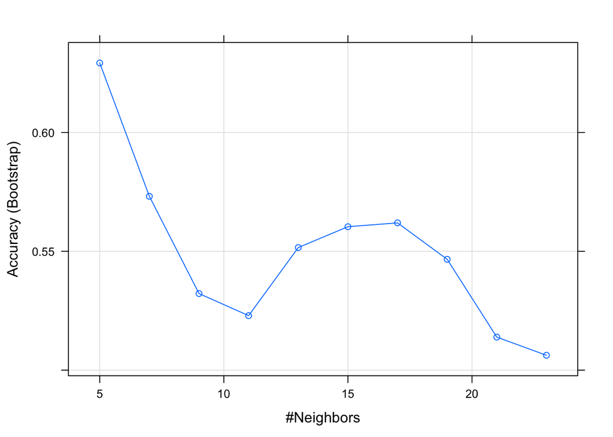

```r
plot(knn_model)
```

We see we obtain the same value of k first selected.

We can plot the test prediction and confirm we obtain the same results with this library.

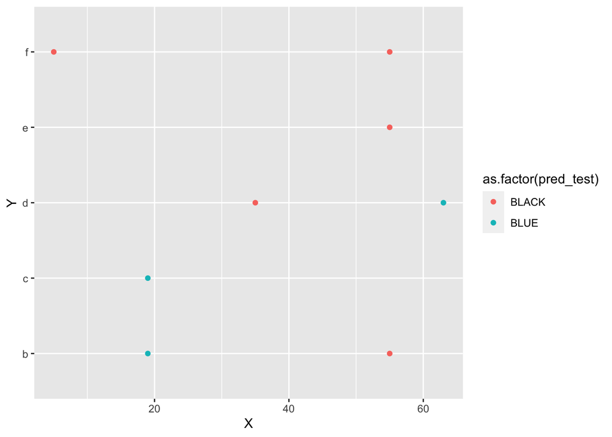

```r
pred_test<-predict(knn_model,newdata = data_test)
ggplot(data_test,aes(y=Y,x=X,color=as.factor(pred_test))) + geom_point()
```

**kNN Results**

```r
results<-data.frame(c(knn_auc,knn_acc,knn_tpr,knn_fpr))
rownames(results)<-c('AUC','ACC','TPR','FPR')
colnames(results)<-c('kNN')
```

## Tree

```r
tree_model<-C5.0(label~.,data=data_train)
tree_model
```

```
##
## Call:
## C5.0.formula(formula = label ~ ., data = data_train)
##
## Classification Tree
## Number of samples: 28
## Number of predictors: 2
##
## Tree size: 1
##
## Non-standard options: attempt to group attributes
```

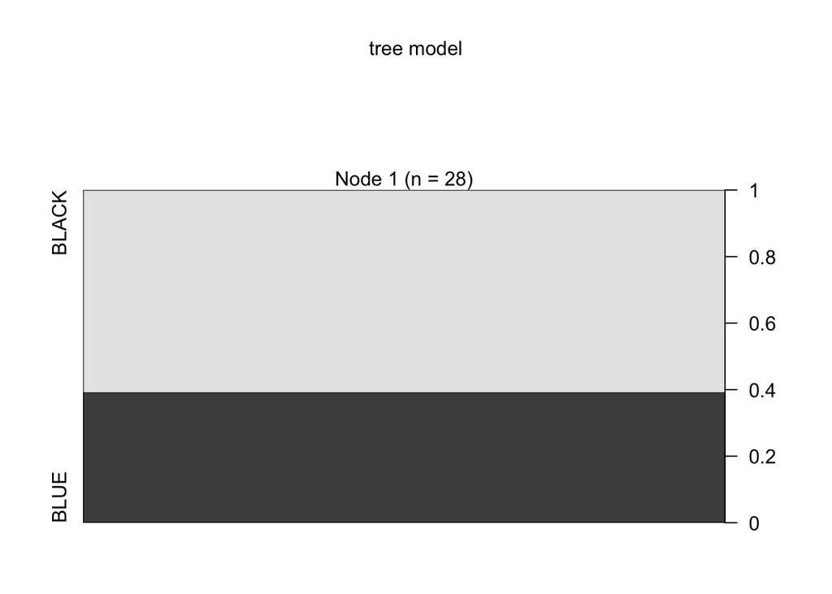

```r
plot(as.party(tree_model),main = "tree model")
```

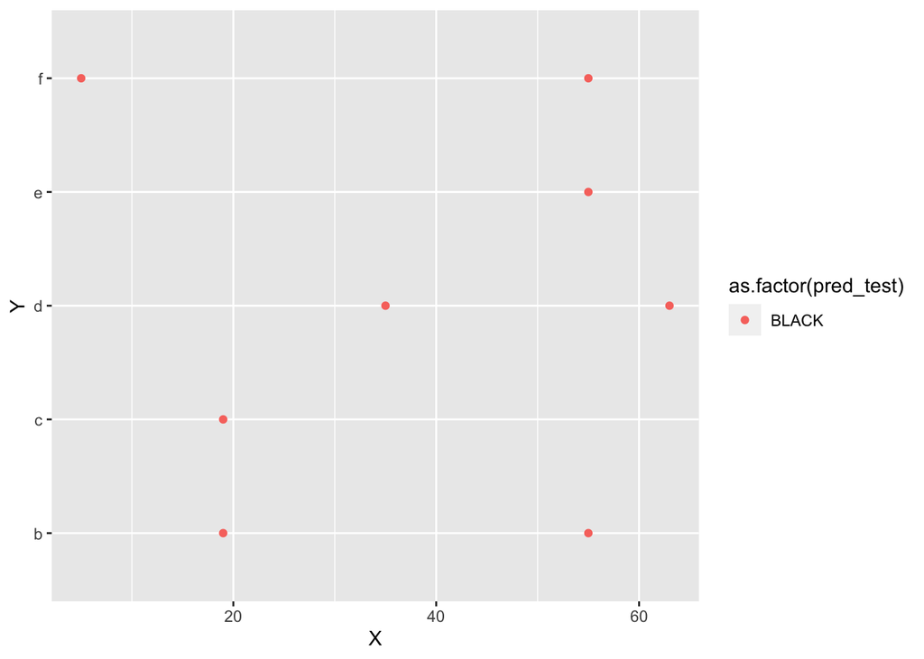

```r
pred_test<-predict(tree_model,newdata = data_test)
ggplot(data_test,aes(y=Y,x=X,color=as.factor(pred_test))) + geom_point()
```

**AUC**

```r
pred_test<-predict(tree_model,newdata = data_test,type="prob")
as.data.frame(pred_test)$BLACK
```

```
## [1] 0.6071429 0.6071429 0.6071429 0.6071429 0.6071429 0.6071429 0.6071429
## [8] 0.6071429
```

```r
(tree_auc<-roc(data_test$label,as.data.frame(pred_test)$BLACK)$auc)
```

```
## Area under the curve: 0.5
```

**ACC**

```r
pred_test<-predict(tree_model,newdata = data_test)
(tree_acc<-mean(pred_test == data_test$label))
```

```
## [1] 0.625
```

**Confusion Matrix**

```r
pred_test<-predict(tree_model,newdata = data_test)
print("BLACK are positives")
```

```
## [1] "BLACK are positives"
```

```r
(confusion_matrix<-table(pred_test,data_test$label))
```

```
##
## pred_test BLACK BLUE
##     BLACK     5    3
##     BLUE      0    0
```

**TPR**

```r
print(paste("Number of true positives=",confusion_matrix[1,1]))
```

```
## [1] "Number of true positives= 5"
```

```r
tree_tpr<-confusion_matrix[1,1]/sum(confusion_matrix[,1])
print(paste("True positive ratio=",tree_tpr))
```

```
## [1] "True positive ratio= 1"
```

**FPR**

```r
print(paste("Number of false positives=",confusion_matrix[2,1]))
```

```
## [1] "Number of false positives= 0"
```

```r
tree_fpr<-confusion_matrix[2,1]/sum(confusion_matrix[,1])
print(paste("False positive ratio=",tree_fpr))
```

```
## [1] "False positive ratio= 0"
```

**Tree Results**

```r
results<-cbind(results,data.frame(c(tree_auc,tree_acc,tree_tpr,tree_fpr)))
colnames(results)<-c('kNN','Tree')
```

## Naive Bayes

```r
nb_model<-naive_bayes(label~.,data=data_train)
nb_model
```

```
##
## ================================== Naive Bayes ==================================
##
##  Call:
## naive_bayes.formula(formula = label ~ ., data = data_train)
##
## ---------------------------------------------------------------------------------
##
## Laplace smoothing: 0
##
## ---------------------------------------------------------------------------------
##
##  A priori probabilities:
##
##     BLACK      BLUE
## 0.6071429 0.3928571
##
## ---------------------------------------------------------------------------------
##
##  Tables:
##
## ---------------------------------------------------------------------------------
##  ::: X (Gaussian)
## ---------------------------------------------------------------------------------
##
## X         BLACK     BLUE
##   mean 38.64706 36.81818
##   sd   19.35504 24.33852
##
## ---------------------------------------------------------------------------------
##  ::: Y (Categorical)
## ---------------------------------------------------------------------------------
##
## Y        BLACK       BLUE
##   a 0.23529412 0.18181818
##   b 0.17647059 0.09090909
##   c 0.05882353 0.36363636
##   d 0.17647059 0.09090909
##   e 0.23529412 0.09090909
##   f 0.11764706 0.18181818
##
## ---------------------------------------------------------------------------------
```

```r
pred_test<-predict(nb_model,data_test)
```

```r
ggplot(data_test,aes(y=Y,x=X,color=as.factor(pred_test))) + geom_point()
```

[output not shown]

**AUC**

```r
pred_test<-predict(nb_model,data_test,type = "prob")
as.data.frame(pred_test)$BLACK
```

```
## [1] 0.3947491 0.7465890 0.1971181 0.7879742 0.7772706 0.8231029 0.5377328
## [8] 0.7530158
```

```r
(nb_auc<-roc(data_test$label,as.data.frame(pred_test)$BLACK)$auc)
```

```
## Area under the curve: 0.7333
```

**ACC**

```r
pred_test<-predict(nb_model,data_test)
(nb_acc<-mean(pred_test == data_test$label))
```

```
## [1] 0.625
```

**Confusion Matrix**

```r
print("BLACK are positives")
```

```
## [1] "BLACK are positives"
```

```r
(confusion_matrix<-table(pred_test,data_test$label))
```

```
##
## pred_test BLACK BLUE
##     BLACK     4    2
##     BLUE      1    1
```

**TPR**

```r
print(paste("Number of true positives=",confusion_matrix[1,1]))
```

```
## [1] "Number of true positives= 4"
```

```r
nb_tpr<-confusion_matrix[1,1]/sum(confusion_matrix[,1])
print(paste("True positive ratio=",nb_tpr))
```

```
## [1] "True positive ratio= 0.8"
```

**FPR**

```r
print(paste("Number of false positives=",confusion_matrix[2,1]))
```

```
## [1] "Number of false positives= 1"
```

```r
nb_fpr<-confusion_matrix[2,1]/sum(confusion_matrix[,1])
print(paste("False positive ratio=",nb_fpr))
```

```
## [1] "False positive ratio= 0.2"
```

**Naive Bayes Results**

```r
results<-cbind(results,data.frame(c(nb_auc,nb_acc,nb_tpr,nb_fpr)))
colnames(results)<-c('kNN','Tree','NB')
```

## LDA

```r
lda_model<-lda(label~.,data=data_train)
lda_model
```

```
## Call:
## lda(label ~ ., data = data_train)
##
## Prior probabilities of groups:
##     BLACK      BLUE
## 0.6071429 0.3928571
##
## Group means:
##              X         Yb         Yc         Yd         Ye        Yf
## BLACK 38.64706 0.17647059 0.05882353 0.17647059 0.23529412 0.1176471
## BLUE  36.81818 0.09090909 0.36363636 0.09090909 0.09090909 0.1818182
##
## Coefficients of linear discriminants:
##            LD1
## X  -0.01187782
## Yb -0.40793331
## Yc  2.36282013
## Yd -0.47920022
## Ye -0.70258013
## Yf  0.87525571
```

```r
pred_test<-predict(lda_model,data_test)[1]$class
ggplot(data_test,aes(y=Y,x=X,color=as.factor(pred_test))) + geom_point()
```

[output not shown]

**AUC**

```r
pred_test<-predict(lda_model,data_test,type = "prob")
df<-as.data.frame(pred_test$posterior[,1])
colnames(df)<-c('black')
(lda_auc<-roc(data_test$label,df$black)$auc)
```

```
## Area under the curve: 0.6
```

**ACC**

```r
pred_test<-predict(lda_model,data_test)[1]$class
(lda_acc<-mean(pred_test == data_test$label))
```

```
## [1] 0.625
```

**Confusion Matrix**

```r
print("BLACK are positives")
```

```
## [1] "BLACK are positives"
```

```r
(confusion_matrix<-table(pred_test,data_test$label))
```

```
##
## pred_test BLACK BLUE
##     BLACK     4    2
##     BLUE      1    1
```

**TPR**

```r
print(paste("Number of true positives=",confusion_matrix[1,1]))
```

```
## [1] "Number of true positives= 4"
```

```r
lda_tpr<-confusion_matrix[1,1]/sum(confusion_matrix[,1])
print(paste("True positive ratio=",lda_tpr))
```

```
## [1] "True positive ratio= 0.8"
```

**FPR**

```r
print(paste("Number of false positives=",confusion_matrix[2,1]))
```

```
## [1] "Number of false positives= 1"
```

```r
lda_fpr<-confusion_matrix[2,1]/sum(confusion_matrix[,1])
print(paste("False positive ratio=",lda_fpr))
```

```
## [1] "False positive ratio= 0.2"
```

**LDA Results**

```r
results<-cbind(results,data.frame(c(lda_auc,lda_acc,lda_tpr,lda_fpr)))
colnames(results)<-c('kNN','Tree','NB','LDA')
```

## Logistic Regression

```r
lr_model<-glm(label~.,data=data_train,family="binomial"(link="logit"))
lr_model
```

```
##
## Call:  glm(formula = label ~ ., family = binomial(link = "logit"), data = data_train)
##
## Coefficients:
## (Intercept)            X           Yb           Yc           Yd           Ye
##    -0.22366     -0.01264     -0.40684      2.15833     -0.48190     -0.74622
##          Yf
##     0.75470
##
## Degrees of Freedom: 27 Total (i.e. Null);  21 Residual
## Null Deviance:       37.52
## Residual Deviance: 31.84     AIC: 45.84
```

```r
pred_training<-predict(lr_model,type="response")
pred_training[pred_training<0.5]<-0
pred_training[pred_training>=0.5]<-1
pred_training[pred_training==0]<-"BLACK"
pred_training[pred_training==1]<-"BLUE"

pred_test<-predict(lr_model,type="response",newdata = data_test)
pred_test[pred_test<0.5]<-0
pred_test[pred_test>=0.5]<-1
pred_test[pred_test==0]<-"BLACK"
pred_test[pred_test==1]<-"BLUE"

ggplot(data_test,aes(y=Y,x=X,color=as.factor(pred_test))) + geom_point()
```

[output not shown]

**AUC**

```r
pred_test<-predict(lr_model,type="response",newdata = data_test)
df<-as.data.frame(pred_test)
colnames(df)<-c('black')
(lr_auc<-roc(data_test$label,df$black)$auc)
```

```
## Area under the curve: 0.6
```

**Confusion Matrix**

```r
pred_test<-predict(lr_model,type="response",newdata = data_test)
pred_test[pred_test<0.5]<-0
pred_test[pred_test>=0.5]<-1
pred_test[pred_test==0]<-"BLACK"
pred_test[pred_test==1]<-"BLUE"

print("BLACK are positives")
```

```
## [1] "BLACK are positives"
```

```r
(confusion_matrix<-table(pred_test,data_test$label))
```

```
##
## pred_test BLACK BLUE
##     BLACK     4    2
##     BLUE      1    1
```

**ACC**

```r
(lr_acc<-sum(diag(confusion_matrix))/sum(confusion_matrix))
```

```
## [1] 0.625
```

**TPR**

```r
print(paste("Number of true positives=",confusion_matrix[1,1]))
```

```
## [1] "Number of true positives= 4"
```

```r
lr_tpr<-confusion_matrix[1,1]/sum(confusion_matrix[,1])
print(paste("True positive ratio=",lr_tpr))
```

```
## [1] "True positive ratio= 0.8"
```

**FPR**

```r
print(paste("Number of false positives=",confusion_matrix[2,1]))
```

```
## [1] "Number of false positives= 1"
```

```r
lr_fpr<-confusion_matrix[2,1]/sum(confusion_matrix[,1])
print(paste("False positive ratio=",lr_fpr))
```

```
## [1] "False positive ratio= 0.2"
```

**LR Results**

```r
results<-cbind(results,data.frame(c(lr_auc,lr_acc,lr_tpr,lr_fpr)))
colnames(results)<-c('kNN','Tree','NB','LDA','LR')
```

## SVM with RBS Kernel

```r
svm_model<-svm(label ~ ., data = data_train,cost=5, cross=10,type="C-classification",kernel="radial",na.action=na.omit)
svm_model
```

```
##
## Call:
## svm(formula = label ~ ., data = data_train, cost = 5, cross = 10,
##     type = "C-classification", kernel = "radial", na.action = na.omit)
##
##
## Parameters:
##    SVM-Type:  C-classification
##  SVM-Kernel:  radial
##        cost:  5
##
## Number of Support Vectors:  21
```

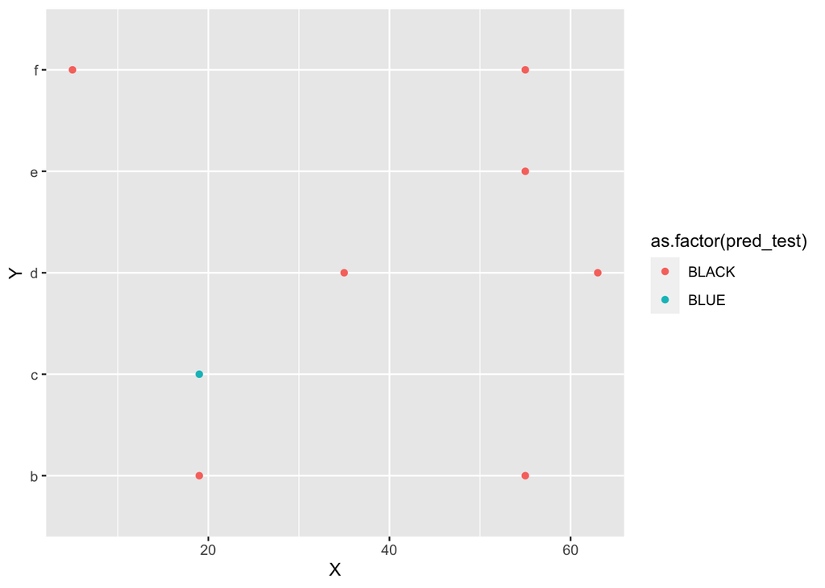

```r
pred_test<- predict(svm_model, data_test)
ggplot(data_test,aes(y=Y,x=X,color=as.factor(pred_test))) + geom_point()
```

**AUC**

```r
class1.svm.model <- svm(label ~ ., data = data_train,cost=20, cross=10,type="C-classification",kernel="radial",na.action=na.omit)
class1.svm.pred <- predict(class1.svm.model, data_test)
finalmatrix<-data.matrix(svm_model, rownames.force = F)

test<-table(pred = pred_test, true = data_test[,3])

confusionMatrix(test)
```

```
## Confusion Matrix and Statistics
##
##        true
## pred    BLACK BLUE
##   BLACK     5    2
##   BLUE      0    1
##
##                Accuracy : 0.75
##                  95% CI : (0.3491, 0.9681)
##     No Information Rate : 0.625
##     P-Value [Acc > NIR] : 0.3697
##
##                   Kappa : 0.3846
##
##  Mcnemar's Test P-Value : 0.4795
##
##             Sensitivity : 1.0000
##             Specificity : 0.3333
##          Pos Pred Value : 0.7143
##          Neg Pred Value : 1.0000
##              Prevalence : 0.6250
##          Detection Rate : 0.6250
##    Detection Prevalence : 0.8750
##       Balanced Accuracy : 0.6667
##
##        'Positive' Class : BLACK
##
```

```r
roc_svm_test <- roc(response = data_test$label, predictor =as.numeric(pred_test))
(svm_auc<-roc_svm_test$auc)
```

```
## Area under the curve: 0.6667
```

**ACC**

```r
svm_model<-svm(label~.,data=data_train,kernel="radial",cost=5)
(svm_acc<-mean(pred_test == data_test$label))
```

```
## [1] 0.75
```

**Confusion Matrix**

```r
print("BLACK are positives")
```

```
## [1] "BLACK are positives"
```

```r
(confusion_matrix<-table(pred_test,data_test$label))
```

```
##
## pred_test BLACK BLUE
##     BLACK     5    2
##     BLUE      0    1
```

**TPR**

```r
print(paste("Number of true positives=",confusion_matrix[1,1]))
```

```
## [1] "Number of true positives= 5"
```

```r
svm_tpr<-confusion_matrix[1,1]/sum(confusion_matrix[,1])
print(paste("True positive ratio=",svm_tpr))
```

```
## [1] "True positive ratio= 1"
```

**FPR**

```r
print(paste("Number of false positives=",confusion_matrix[2,1]))
```

```
## [1] "Number of false positives= 0"
```

```r
svm_fpr<-confusion_matrix[2,1]/sum(confusion_matrix[,1])
print(paste("False positive ratio=",svm_fpr))
```

```
## [1] "False positive ratio= 0"
```

```r
results<-cbind(results,data.frame(c(svm_auc,svm_acc,svm_tpr,svm_fpr)))
colnames(results)<-c('kNN','Tree','NB','LDA','LR','SVM')
```

# Summary classifier performance

Summarize and provide a explanatory commentary on the observed performance of these classifiers

```r
results %>% kable() %>% kable_styling() %>% scroll_box(width = "800px")
```

|  | kNN | Tree | NB | LDA | LR | SVM |
| --- | --- | --- | --- | --- | --- | --- |
| AUC | 0.7666667 | 0.500 | 0.7333333 | 0.600 | 0.600 | 0.6666667 |
| ACC | 1.0000000 | 0.625 | 0.6250000 | 0.625 | 0.625 | 0.7500000 |
| TPR | 1.0000000 | 1.000 | 0.8000000 | 0.800 | 0.800 | 1.0000000 |
| FPR | 0.0000000 | 0.000 | 0.2000000 | 0.200 | 0.200 | 0.0000000 |

At first glance it will seem that all classifiers have similar performance. But a second look shows more details. First to keep in mind, metrics were computed agains a rather small sample size, the test set, with only 8 samples. This is a very small set, so small changes in performance affect the metrics substantially.

# Classifier Performance differences

What aspects of the data and or aspects of the algorithms, explain these performance differences

A quick look at the scattered plots for the entire dataset and the training and test sets reveals how it isn’t really easy to draw linear classifiers to serrate the different classes. We see many samples of different classes intertwined between each other.This makes it harder for several of these classifier to properly assign classes.

At the other extreme, classifiers such as SVM with a non linear kernel do better at classifying this kind of data, mainly because the kernel allows the classifier work in higher dimension that now do show the data segregated.